# DAS. Final Project

Dmitri Bobrikov

21 Март, 2024

# 1. Introduction.

The exploration of household financial satisfaction within diverse national contexts is deeply entrenched in the examination of broader societal frameworks and dynamics. Sociological inquiry delves into the intricate interplay between macro-level determinants, such as educational attainment, religiosity, and political coordination, and the ensuing ramifications for individual and household economic well-being.

Theoretical paradigms within sociology, including structural functionalism, social capital theory, and symbolic interactionism, offer nuanced insights into the mechanisms by which external factors exert influence on financial satisfaction. Structural functionalism posits the symbiotic relationship between social institutions, wherein education, religiosity, and political coordination are construed as fundamental constituents of societal structure, each contributing distinctively to the operational efficiency of the social fabric.

Education emerges as a pivotal determinant of human capital accumulation, thereby not only shaping individual earning potential but also modulating perceptions of economic opportunities and aspirations. Conversely, religiosity serves as a locus for the cultivation of social support networks, normative frameworks, and value systems that indelibly influence financial behaviors and decision-making processes within households. Furthermore, the degree of political coordination within a society reflects the efficacy of collective action and governance mechanisms, thereby exerting profound impacts on economic policy formulation, income distribution dynamics, and overall financial well-being.

Transitioning cogently from this sociological backdrop to the research question, our study seeks to empirically investigate the complex interrelationships between the aforementioned external determinants—average educational attainment, average religiosity, and average political coordination—and household financial satisfaction across an array of national contexts. Specifically, we inquire: *“How do the external factors such as average educational level, average religiosity, and average political coordination influence financial satisfaction in households across different countries?”*. By scrutinizing these intricate linkages, our research endeavors to elucidate the nuanced ways in which societal-level dynamics intersect with individual economic experiences, thereby enriching scholarly understanding in the field.

The impetus for undertaking this research is underscored by the imperative to comprehend the multifaceted determinants of household financial satisfaction within heterogeneous socio-cultural milieus. Insights garnered from this inquiry hold significant implications for the formulation of evidence-based policy interventions aimed at bolstering economic well-being and ameliorating disparities across diverse national contexts. Moreover, by interrogating the roles of education, religiosity, and political coordination, our study contributes substantively to theoretical advancements within sociology, unraveling the intricate interplay between macro-level social structures and micro-level economic outcomes.

# 2. Hypotheses.

Educational Attainment Hypothesis:

H1: Higher average educational attainment within a country is positively associated with household financial satisfaction, as individuals with higher levels of education tend to have greater access to job opportunities, higher incomes, and financial literacy skills.

Religiosity Hypothesis:

H2: Increased religiosity within a country is positively related to household financial satisfaction, as religious institutions may provide social support networks, moral guidance, and assistance during times of economic hardship, thereby buffering financial stress and enhancing satisfaction.

Political Coordination Hypothesis:

H3: Higher levels of political coordination within a country are positively correlated with household financial satisfaction, as effective governance structures and policies can lead to stable economic conditions, equitable distribution of resources, and favorable business environments, fostering greater satisfaction among households.

Also, we would like to see whether there are some differences between migrants/non-migrants and people who consider that mostly people can be trusted/they should be very careful. H4: We assume that we will observe differences among these groups in terms of their financial satisfaction of household.

All these hypotheses will be testes using multilevel modelling with country variable as well to reveal insights in the field.

# 3. Methodology

## Data Preparation

### Choice of Predictors

As the 1st level predictors, we would like to use $Q57$ - general trust, $Q260$ - sex, $Q262$ - age and $Q263$ - migrant status. For the 2nd level predictors, we will use $B.COUNTRY$ - country, and aggregated versions (means) of $Q164$ - scale of God’s importance in life, $Q240$ - liberal-conservative scale and $Q275$ - educational level.

```r
library(dplyr)
library(sjPlot)
library(ggplot2)
library(mice)
library(miceadds)
library(doParallel)
library(mi)
library(misty)
library(lme4)
library(performance)
library(lattice)
library(effects)
load("~/rrrr/das3/WVS_Cross-National_Wave_7_rData_v5_0.Rdata")
df = `WVS_Cross-National_Wave_7_v5_0` %>% select(B_COUNTRY, Q50, Q57, Q164, Q240, Q260, Q262, Q263, Q275)
head(df)
```

|  | B_COUNTRY | Q50 | Q57 | Q164 | Q240 | Q260 | Q262 | Q263 | Q275 |
| --- | --- | --- | --- | --- | --- | --- | --- | --- | --- |
| 1 | 20 | 5 | 2 | 7 | 6 | 2 | 60 | 2 | 3 |
| 2 | 20 | 9 | 2 | 1 | 5 | 1 | 47 | 1 | 7 |
| 3 | 20 | 8 | 2 | 8 | 7 | 1 | 48 | 2 | 7 |
| 4 | 20 | 6 | 2 | 1 | 5 | 2 | 62 | 2 | 2 |
| 5 | 20 | 7 | 2 | 4 | 6 | 1 | 49 | 2 | 2 |
| 6 | 20 | 6 | 2 | 3 | -2 | 2 | 51 | 2 | 1 |

- $B.COUNTRY$ - country
- $Q50$ - financial situation in household satisfaction (1 - completely dissatisfied, 10 - completely satisfied)
- $Q57$ - general trust (1 - Most people can be trusted, 2 - Need to be very careful)
- $Q164$ - how important god in your life (1 - not at all, 10 - very important)
- $Q240$ - liberal-conservative scale (1 - left, 10 - right)
- $Q260$ - sex (1 - male, 2 - female)
- $Q262$ - age
- $Q263$ - migrant status (1 - born in country, 2 - outside the country)
- $Q275$ - respondent’s education (0 - no education, 8 - doctor or equivalent)

### Types of Variables

Let’s see the classes of variables in dataset

```r
paste0("B_COUNTRY is ", class(df$B_COUNTRY))
```

```
## [1] "B_COUNTRY is integer"
```

```r
paste0("Q50 is ", class(df$Q50))
```

```
## [1] "Q50 is integer"
```

```r
paste0("Q57 is ", class(df$Q57))
```

```
## [1] "Q57 is integer"
```

```r
paste0("Q164 is ", class(df$Q164))
```

```
## [1] "Q164 is integer"
```

```r
paste0("Q240 is ", class(df$Q240))
```

```
## [1] "Q240 is integer"
```

```r
paste0("Q260 is ", class(df$Q260))
```

```
## [1] "Q260 is integer"
```

```r
paste0("Q262 is ", class(df$Q262))
```

```
## [1] "Q262 is integer"
```

```r
paste0("Q263 is ", class(df$Q263))
```

```
## [1] "Q263 is integer"
```

```r
paste0("Q275 is ", class(df$Q275))
```

```
## [1] "Q275 is integer"
```

We can see that all variables are perceived as integer though it is not what we need: country, sex, migrant status, general trust should be factor and all others should be numeric. Let’s fix it.

```r
df$B_COUNTRY = as.factor(df$B_COUNTRY)
df$Q50 = as.numeric(df$Q50)
df$Q57 = as.factor(as.character(df$Q57))
df$Q164 = as.numeric(df$Q164)
df$Q240 = as.numeric(df$Q240)
df$Q260 = as.factor(as.character(df$Q260))
df$Q262 = as.numeric(df$Q262)
df$Q263 = as.factor(as.character(df$Q263))
df$Q275 = as.numeric(df$Q275)

paste0("B_COUNTRY is ", class(df$B_COUNTRY))
```

```
## [1] "B_COUNTRY is factor"
```

```r
paste0("Q50 is ", class(df$Q50))
```

```
## [1] "Q50 is numeric"
```

```r
paste0("Q57 is ", class(df$Q57))
```

```
## [1] "Q57 is factor"
```

```r
paste0("Q164 is ", class(df$Q164))
```

```
## [1] "Q164 is numeric"
```

```r
paste0("Q240 is ", class(df$Q240))
```

```
## [1] "Q240 is numeric"
```

```r
paste0("Q260 is ", class(df$Q260))
```

```
## [1] "Q260 is factor"
```

```r
paste0("Q262 is ", class(df$Q262))
```

```
## [1] "Q262 is numeric"
```

```r
paste0("Q263 is ", class(df$Q263))
```

```
## [1] "Q263 is factor"
```

```r
paste0("Q275 is ", class(df$Q275))
```

```
## [1] "Q275 is numeric"
```

Now it’s all right. Before we proceed to mutating our aggregated variables, we should recode our variables as they have negative values that mean NAs. If we don’t recode beforehand, we will obtain wrong results of mean variables.

```r
df$fin_sat <- ifelse(df$Q50 < 0, NA, df$Q50)
df = df %>% mutate(gen_trust = case_when(df$Q57 == "1" ~ df$Q57,
                                         df$Q57 == "2" ~ df$Q57,
                                         TRUE ~ NA))
df$god <- ifelse(df$Q164 < 0, NA, df$Q164)
df$lib_con <- ifelse(df$Q240 <0, NA, df$Q240)
df = df %>% mutate(sex = case_when(df$Q260 == "1" ~ df$Q260,
                                   df$Q260 == "2" ~ df$Q260,
                                   TRUE ~ NA))
df$age <- ifelse(df$Q262 <1, NA, df$Q262)
df = df %>% mutate(migrant = case_when(df$Q263 == "1" ~ df$Q263,
                                       df$Q263 == "2" ~ df$Q263,
                                       TRUE ~ NA))
df$ed <- ifelse(df$Q275 <1, NA, df$Q275)
df = df %>% select(-Q50, -Q57, -Q164, -Q240, -Q260, -Q262, -Q263, -Q275)
head(df)
```

|  | B_COUNTRY | fin_sat | gen_trust | god | lib_con | sex | age | migrant | ed |
| --- | --- | --- | --- | --- | --- | --- | --- | --- | --- |
| 1 | 20 | 5 | 2 | 7 | 6 | 2 | 60 | 2 | 3 |
| 2 | 20 | 9 | 2 | 1 | 5 | 1 | 47 | 1 | 7 |
| 3 | 20 | 8 | 2 | 8 | 7 | 1 | 48 | 2 | 7 |
| 4 | 20 | 6 | 2 | 1 | 5 | 2 | 62 | 2 | 2 |
| 5 | 20 | 7 | 2 | 4 | 6 | 1 | 49 | 2 | 2 |
| 6 | 20 | 6 | 2 | 3 | NA | 2 | 51 | 2 | 1 |

Now we have NAs, and we can create aggregated variables.

```r
# god importance variable
df<-df %>%
  group_by(B_COUNTRY) %>%
  mutate(mean_god = mean(god, na.rm=T)) %>% ungroup()

# liberal-conservative scale
df<-df %>%
  group_by(B_COUNTRY) %>%
  mutate(mean_lib_con = mean(lib_con, na.rm=T)) %>% ungroup()

# education
df<-df %>%
  group_by(B_COUNTRY) %>%
  mutate(mean_ed = mean(ed, na.rm=T)) %>% ungroup()

df = df %>% select(-god, -lib_con, -ed)

table(df$mean_god)
```

```
##
## 2.80330578512397 3.74083634486319  4.0880626223092  4.0957528957529
##             3036             2145             1023             2609
##  4.2191435768262 4.46331658291457 4.52166934189406 4.76305220883534
##             1200             1057             1353             1004
## 4.78476084538376 4.80786460925834 4.92042440318302 4.93586005830904
##             1813             4018             1528             2075
## 5.03614457831325 5.06009453072248 5.58740831295844 6.01797752808989
##             1245             1500             1638              447
##           6.0275  6.1005723630417 6.29312354312354 6.31864406779661
##             1200             1223             1810             1200
## 6.55533199195171 6.63951120162933 6.71761055081458 6.72513743128436
##             1000             1000             2596             2012
## 6.78799612778316 7.05968928863451 7.14874371859297 7.66045380875203
##             1046             1289             1003             1276
## 7.79685863874346 7.92173189009159 8.07426160337553 8.13803169307756
##             1000             1208             1200             2415
## 8.45696877380046 8.60528488852188  8.6129959746981 8.65492393915132
##             1313             1229             1741             1257
##           8.9825           8.9925 9.03415409054805 9.07507163323782
##             1200             1200             1266             1762
## 9.08798283261803 9.11008403361344 9.15441783649876 9.20833333333333
##             1400             1190             1223             1200
## 9.23333333333333 9.23970944309927 9.29239766081871 9.31315789473684
##             1200             2067             1200             1520
## 9.32461677186655 9.33711615487316 9.42618849040867 9.45998383185125
##             1127             1499             1200             1237
## 9.50960735171262 9.52602324406266            9.555 9.66083333333333
##             1203             1995             1200             1200
##            9.705        9.7709375 9.82113821138211 9.82701812191104
##             1200             3200             1230             1215
## 9.87584215591915 9.88235294117647 9.95735785953177
##             1039             1196             1200
```

On the example of aggregated variable of God’s importance, we can see that it’s all great and we do not have negative values.

### Distributions

Let’s plot distributions of our variables.

*Country*

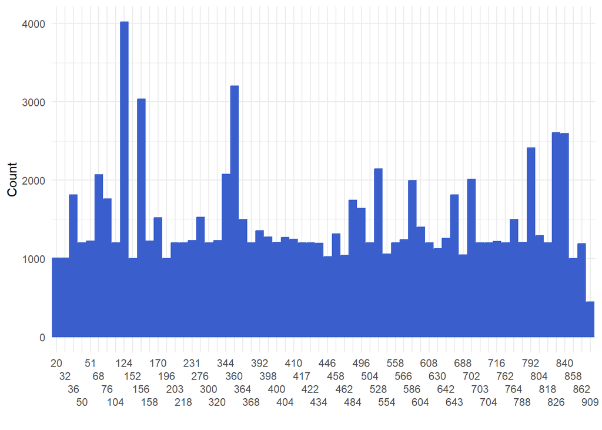

Figure 1. Country Distribution

```r
ggplot(df, aes( x = B_COUNTRY))+
  geom_bar(colour = '#3A5FCD', fill = '#3A5FCD') +
  xlab(" ")+
  ylab("Count") +
  scale_x_discrete(guide = guide_axis(n.dodge=4)) +
  theme_minimal()
```

On average, all countries have more than 1000 observations, though there are some extreme cases such as #124 (~4000 observations) and #909 (<500 observations).

*Financial Situation in Household Satisfaction*

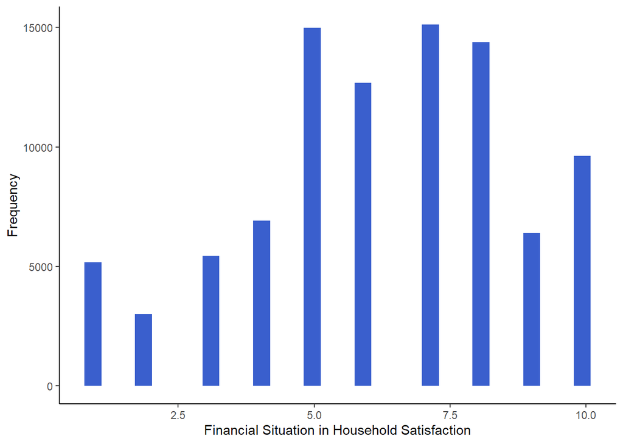

Figure 2. Distribution of Financial Situation in Household Satisfaction

```r
ggplot(df, aes(x = fin_sat)) +
  geom_histogram(fill = "#3A5FCD") +
  xlab("Financial Situation in Household Satisfaction")+
  ylab("Frequency")+
  theme_classic()
```

In general, it looks like the majority of people are satisfied with their financial situation in household (>= 5 points).

*General Trust*

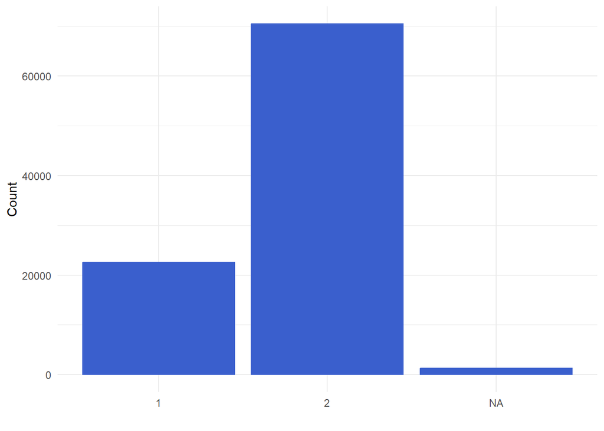

Figure 3. General Trust Distribution

```r
ggplot(df, aes( x = gen_trust))+
  geom_bar(colour = '#3A5FCD', fill = '#3A5FCD') +
  xlab(" ")+
  ylab("Count") +
  theme_minimal()
```

We have a few NAs, but despite them people mostly prefer to be very careful and there are much less people who consider that most people can be trusted.

*God Importance* (on a country level)

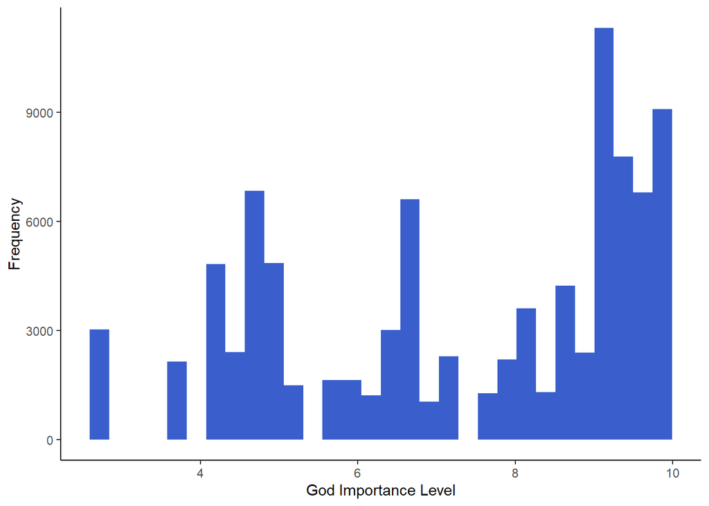

Figure 4. Distribution of God Importance Level

```r
ggplot(df, aes( x = mean_god))+
  geom_histogram(fill = "#3A5FCD") +
  xlab("God Importance Level")+
  ylab("Frequency")+
  theme_classic()
```

We can notice that we have some kind of three groups here: 1) highly religious (from around 8 to 10 points), 2) moderately religious (from around 6 to 8 points) and 3) low religious (lower than 6 points) people in countries. Moreover, the group of highly religious is bigger than others

*Liberal-Conservative Scale* (on a country level)

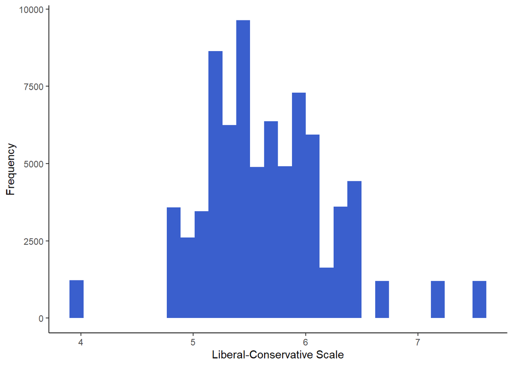

Figure 5. Distribution of Liberal-Conservative Scale

```r
ggplot(df, aes( x = mean_lib_con))+
  geom_histogram(fill = "#3A5FCD") +
  xlab("Liberal-Conservative Scale")+
  ylab("Frequency")+
  theme_classic()
```

Here we can notice that many people consider them as centrists (in the middle between liberal and conservative/left and right).

*Sex*

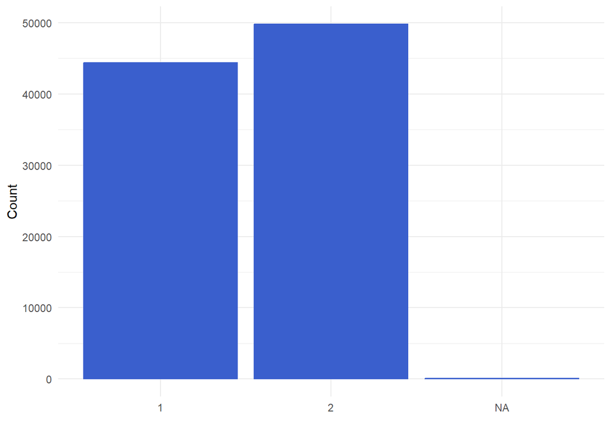

Figure 6. Sex Distribution

```r
ggplot(df, aes( x = sex))+
  geom_bar(colour = '#3A5FCD', fill = '#3A5FCD') +
  xlab(" ")+
  ylab("Count") +
  theme_minimal()
```

We can see that there is almost 50/50 distribution of men and women though the number of females is a little more than males. Also, we have a few NAs.

*Age*

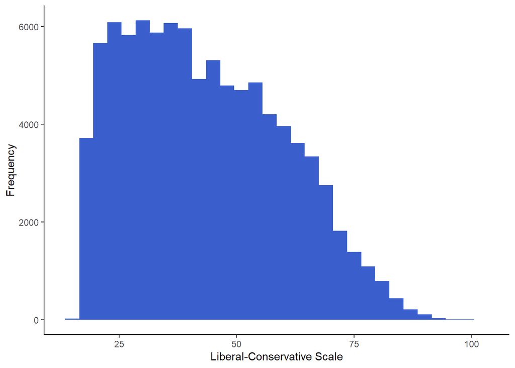

Figure 7. Age Distribution

```r
ggplot(df, aes( x = age))+
  geom_histogram(fill = "#3A5FCD") +
  xlab("Liberal-Conservative Scale")+
  ylab("Frequency")+
  theme_classic()
```

We can see that respondents mostly are older 16 years. The majority of people fits in the interval from 16 to 55 years.

*Migrant Status*

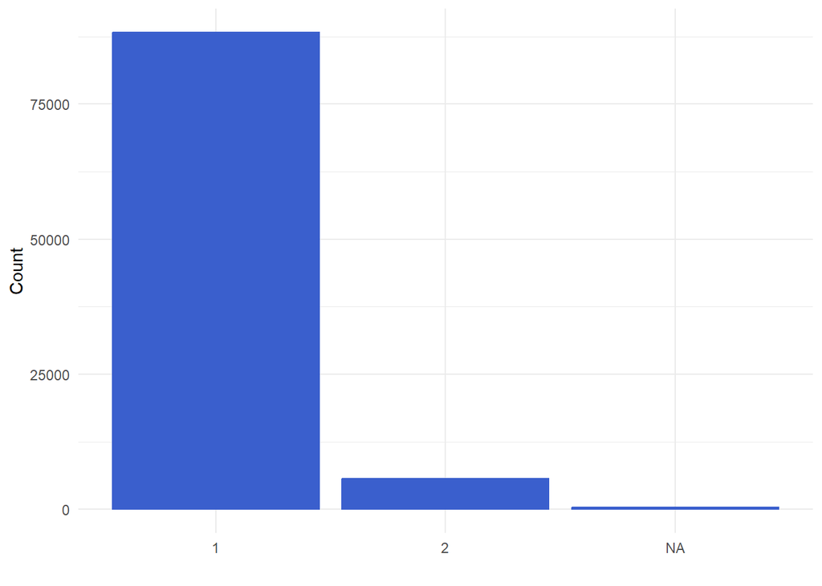

Figure 8. Distribution of Migrant Status

```r
ggplot(df, aes( x = migrant))+
  geom_bar(colour = '#3A5FCD', fill = '#3A5FCD') +
  xlab(" ")+
  ylab("Count") +
  theme_minimal()
```

We can see that mostly people were born inside the country of where the survey took place. There are a few missings.

*Education* (on a country level)

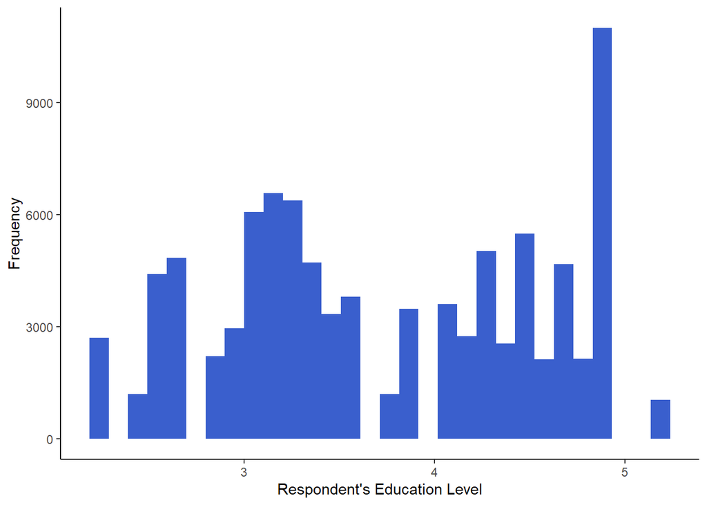

Figure 9. Distribution of Education Level

```r
ggplot(df, aes( x = mean_ed))+
  geom_histogram(fill = "#3A5FCD") +
  xlab("Respondent's Education Level")+
  ylab("Frequency")+
  theme_classic()
```

Based on all plots, we assume that all categories in all variables are saturated, except for missings but we will deal with them in the next section.

## Missings

We have already recoded our negative values into NAs, so now we can easily proceed to analysis of them and to imputation later.

Let’s see the summary of our data to check the number of NAs for each variable.

```r
summary(df)
```

```
##    B_COUNTRY        fin_sat       gen_trust      sex             age
##  124    : 4018   Min.   : 1.000   -1  :    0   -1  :    0   Min.   : 16.00
##  360    : 3200   1st Qu.: 5.000   -2  :    0   -2  :    0   1st Qu.: 30.00
##  156    : 3036   Median : 6.000   -5  :    0   -5  :    0   Median : 41.00
##  826    : 2609   Mean   : 6.198   1   :22552   1   :44403   Mean   : 43.41
##  840    : 2596   3rd Qu.: 8.000   2   :70453   2   :49780   3rd Qu.: 56.00
##  792    : 2415   Max.   :10.000   NA's: 1273   NA's:   95   Max.   :103.00
##  (Other):76404   NA's   :578                                NA's   :510
##  migrant         mean_god      mean_lib_con      mean_ed
##  -1  :    0   Min.   :2.803   Min.   :3.960   Min.   :2.206
##  -2  :    0   1st Qu.:5.036   1st Qu.:5.265   1st Qu.:3.101
##  -5  :    0   Median :7.922   Median :5.587   Median :3.554
##  1   :88247   Mean   :7.317   Mean   :5.658   Mean   :3.721
##  2   : 5647   3rd Qu.:9.292   3rd Qu.:5.987   3rd Qu.:4.479
##  NA's:  384   Max.   :9.957   Max.   :7.548   Max.   :5.155
##               NA's   :1200    NA's   :16209
```

The largest number of missings is found in the mean values of political coordinates scale (16209, or almost 17% of data), that’s much… Nevertheless, there is no need for imputation in case of country and mean education level.

Let’s see if there are some patterns of missingness

```r
df2 = as.data.frame(df)
mdf <- missing_data.frame(df2)
mdf <- change(mdf, y = c("age", "mean_god", "mean_lib_con", "mean_ed", "fin_sat"), what = "type", to = "positive-continuous")
mdf <- change(mdf, y = "B_COUNTRY", what = "type", to = "unordered-categorical")
mdf <- change(mdf, y = c("sex", "migrant", "gen_trust"), what = "type", to = "binary")
```

```r
table(mdf@patterns)
```

```
##
##                               nothing                               fin_sat
##                                 75801                                   391
##                             gen_trust                                   age
##                                   930                                   406
##                                   sex                               migrant
##                                    39                                   237
##                          mean_lib_con                    fin_sat, gen_trust
##                                 14825                                    76
##                              sex, age                          age, migrant
##                                    27                                    17
##                 migrant, mean_lib_con               gen_trust, mean_lib_con
##                                    20                                   119
##                 fin_sat, mean_lib_con                    gen_trust, migrant
##                                    30                                    25
##                mean_god, mean_lib_con                      fin_sat, migrant
##                                  1174                                     8
##                        gen_trust, age                          fin_sat, sex
##                                    22                                     2
##                        gen_trust, sex                          fin_sat, age
##                                     4                                     4
##                     age, mean_lib_con                     sex, age, migrant
##                                     9                                    14
##      fin_sat, gen_trust, mean_lib_con        fin_sat, migrant, mean_lib_con
##                                     5                                     1
##     gen_trust, mean_god, mean_lib_con               fin_sat, gen_trust, sex
##                                    26                                     1
##               gen_trust, sex, migrant               fin_sat, gen_trust, age
##                                     1                                     2
##           fin_sat, gen_trust, migrant                   gen_trust, sex, age
##                                    52                                     1
##               gen_trust, age, migrant      fin_sat, gen_trust, age, migrant
##                                     1                                     2
##      fin_sat, gen_trust, sex, migrant          gen_trust, sex, age, migrant
##                                     1                                     2
## fin_sat, gen_trust, sex, age, migrant
##                                     3
```

Let’s figure out why there are so many NAs in combination of aggregated variables about God’s importance level and political coordination scale. Let’s check the God’s importance level first.

```r
df %>% filter(is.na(mean_god)) %>% group_by(B_COUNTRY) %>% summarise(n=n())
```

| B_COUNTRY | n |
| --- | --- |
| 368 | 1200 |

It turns out that all these NAs come from country #368. Let’s delete observations from this country because it will not be imputed with grouping technique by countries.

Now let’s check the same for political coordination scale.

```r
df %>% filter(is.na(mean_lib_con)) %>% group_by(B_COUNTRY) %>% summarise(n=n())
```

| B_COUNTRY | n |
| --- | --- |
| 104 | 1200 |
| 156 | 3036 |
| 364 | 1499 |
| 368 | 1200 |
| 398 | 1276 |
| 400 | 1203 |
| 417 | 1200 |
| 422 | 1200 |
| 586 | 1995 |
| 704 | 1200 |

[output cut: 1 more lines]

In this case, we have 11 countries with NAs for the question about political coordination. We are now able to confirm our hypothesis that one country (#368) have missings in those 2 variables and probably skipped the questions.

We may assume that these missings are not at random (or at random, we never know).

```r
na.test(df2)
```

```
##  Little's MCAR Test
##
##       n nIncomp nPattern    chi2  df  pval
##   94278   18477       35 6973.58 225 0.000
```

Special test even supports this thought. Null hypothesis here - it is MCAR. P-value is less than 0.05, so we reject null hypothesis and this is not MCAR.

Before the imputation, let’s delete countries with all NAs for political coordination and God’s importance level.

```r
df = df %>% filter(B_COUNTRY != "104")
df = df %>% filter(B_COUNTRY != "156")
df = df %>% filter(B_COUNTRY != "364")
df = df %>% filter(B_COUNTRY != "368")
df = df %>% filter(B_COUNTRY != "398")
df = df %>% filter(B_COUNTRY != "400")
df = df %>% filter(B_COUNTRY != "417")
df = df %>% filter(B_COUNTRY != "422")
df = df %>% filter(B_COUNTRY != "586")
df = df %>% filter(B_COUNTRY != "704")
df = df %>% filter(B_COUNTRY != "818")
df = droplevels(df)
df %>% group_by(B_COUNTRY) %>% summarise(n=n())
```

| B_COUNTRY | n |
| --- | --- |
| 20 | 1004 |
| 32 | 1003 |
| 36 | 1813 |
| 50 | 1200 |
| 51 | 1223 |
| 68 | 2067 |
| 76 | 1762 |
| 124 | 4018 |
| 152 | 1000 |
| 158 | 1223 |

[output cut: 43 more lines]

We can see that now our dataset has observation only from 53 countries.

Let’s quickly check whether we still have NAs.

```r
summary(df)
```

```
##    B_COUNTRY        fin_sat       gen_trust      sex             age
##  124    : 4018   Min.   : 1.000   1   :18421   1   :36615   Min.   : 16.00
##  360    : 3200   1st Qu.: 5.000   2   :58525   2   :41359   1st Qu.: 30.00
##  826    : 2609   Median : 6.000   NA's: 1123   NA's:   95   Median : 42.00
##  840    : 2596   Mean   : 6.214                             Mean   : 44.04
##  792    : 2415   3rd Qu.: 8.000                             3rd Qu.: 57.00
##  528    : 2145   Max.   :10.000                             Max.   :103.00
##  (Other):61086   NA's   :542                                NA's   :501
##  migrant         mean_god      mean_lib_con      mean_ed
##  1   :72371   Min.   :3.741   Min.   :3.960   Min.   :2.206
##  2   : 5335   1st Qu.:4.936   1st Qu.:5.265   1st Qu.:3.141
##  NA's:  363   Median :7.797   Median :5.587   Median :3.829
##               Mean   :7.241   Mean   :5.658   Mean   :3.772
##               3rd Qu.:9.154   3rd Qu.:5.987   3rd Qu.:4.538
##               Max.   :9.882   Max.   :7.548   Max.   :5.155
##
```

Yes, we do have them, so now let’s proceed to imputation of missings for each country individually with mice package.

```r
# Divide data into subsets based on 'country' variable
countries <- unique(df$B_COUNTRY)
imputed_data <- data.frame() # create empty dataframe to store imputed data
subset_data <- data.frame()
subset_imp_data <- data.frame()

# Loop through each country subset for imputation
for (country in countries) {
  # Subset the data based on country
  subset_data <- df[df$B_COUNTRY == country,]

  # Create imputation model for the subset
  imp_model <- mice(subset_data, m = 5, meth = 'pmm', seed = 123)

  # Impute missing values in the subset
  subset_imp_data <- tidyr::complete(imp_model)

  # Replace NA with imputed data in the original dataset
  df[df$B_COUNTRY == country,] <- subset_imp_data

  # Add imputed subset data to the imputed_data dataframe
  imputed_data <- rbind(imputed_data, subset_imp_data)
}
```

```r
summary(imputed_data)
```

```
##    B_COUNTRY        fin_sat       gen_trust sex            age
##  124    : 4018   Min.   : 1.000   1:18771   1:36651   Min.   : 16.00
##  360    : 3200   1st Qu.: 5.000   2:59298   2:41418   1st Qu.: 30.00
##  826    : 2609   Median : 6.000                       Median : 42.00
##  840    : 2596   Mean   : 6.215                       Mean   : 44.05
##  792    : 2415   3rd Qu.: 8.000                       3rd Qu.: 57.00
##  528    : 2145   Max.   :10.000                       Max.   :103.00
##  (Other):61086
##  migrant      mean_god      mean_lib_con      mean_ed
##  1:72689   Min.   :3.741   Min.   :3.960   Min.   :2.206
##  2: 5380   1st Qu.:4.936   1st Qu.:5.265   1st Qu.:3.141
##            Median :7.797   Median :5.587   Median :3.829
##            Mean   :7.241   Mean   :5.658   Mean   :3.772
##            3rd Qu.:9.154   3rd Qu.:5.987   3rd Qu.:4.538
##            Max.   :9.882   Max.   :7.548   Max.   :5.155
##
```

```r
df_imp = imputed_data
```

We can see that do not have NAs anymore. Great news!

## Statistical tests

In this section we will conduct statistical tests of the outcome with the predictors we selected earlier.

*Age*

Here we should conduct correlation test as we have two numeric variables.

```r
cor.test(df_imp$fin_sat,df_imp$age)
```

```
##
##  Pearson's product-moment correlation
##
## data:  df_imp$fin_sat and df_imp$age
## t = 9.4566, df = 78067, p-value < 2.2e-16
## alternative hypothesis: true correlation is not equal to 0
## 95 percent confidence interval:
##  0.02681777 0.04083115
## sample estimates:
##        cor
## 0.03382613
```

There is a statistically significant relationship between financial satisfaction level and age (p-value is less than 0.05). Moreover, this relationship is positive that means that the higher the age is the higher the financial satisfaction is. Also, this relationship is weak because coefficient is only 0.03 by modulus.

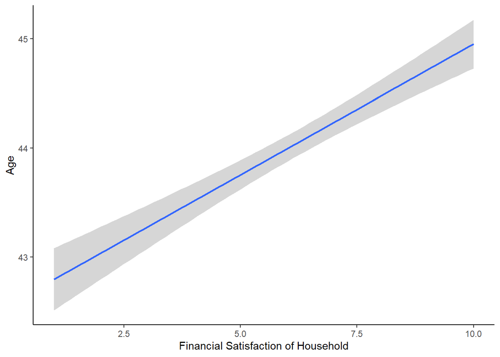

Figure 10. Relationship between Financial Satisfaction and Age

```r
ggplot(df_imp, aes(x = fin_sat, y=age)) +
  xlab("Financial Satisfaction of Household")+
  ylab("Age")+
  geom_smooth(method = "lm")+
  theme_classic()
```

Here is the visualization of this correlation.

*Sex*

Here we should conduct t-test as we have one numeric variable and one binary variable.

```r
t.test(df_imp$fin_sat~df_imp$sex)
```

```
##
##  Welch Two Sample t-test
##
## data:  df_imp$fin_sat by df_imp$sex
## t = 2.9604, df = 77198, p-value = 0.003073
## alternative hypothesis: true difference in means between group 1 and group 2 is not equal to 0
## 95 percent confidence interval:
##  0.01717111 0.08445347
## sample estimates:
## mean in group 1 mean in group 2
##        6.241985        6.191173
```

There is a statistically significant difference between males and females in terms of their financial satisfaction of household level (p-value is less than 0.05). Moreover, males have on average higher score on financial satisfaction level compared to females.

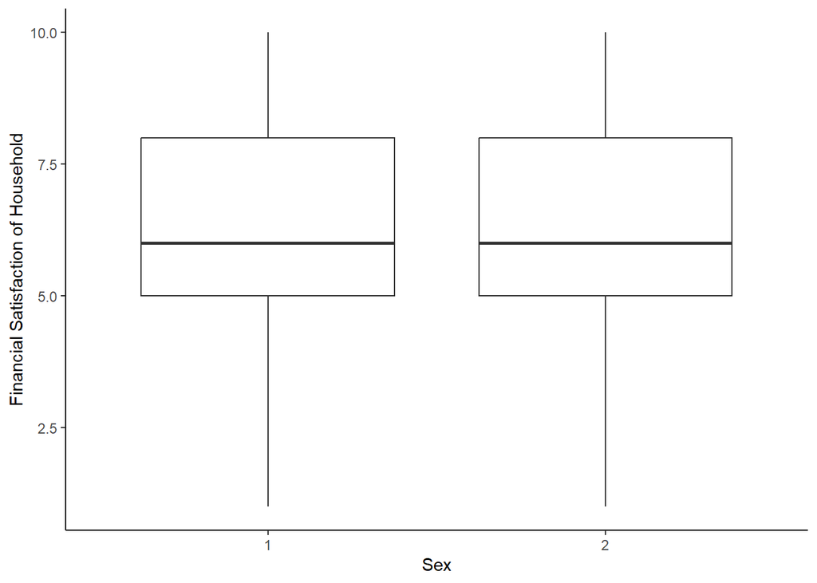

Figure 11. Difference in Means of Financial Satisfaction Level by Sex

```r
ggplot(df_imp, aes(x=sex, y=fin_sat)) +
  geom_boxplot()+
  xlab("Sex")+
  ylab("Financial Satisfaction of Household")+
  theme_classic()
```

We can see that the difference in means is almost invisible.

*Migrant status*

Here we also should conduct t-test as we have one numeric variable and one binary variable.

```r
t.test(df_imp$fin_sat~df_imp$migrant)
```

```
##
##  Welch Two Sample t-test
##
## data:  df_imp$fin_sat by df_imp$migrant
## t = -4.5967, df = 6422.8, p-value = 4.375e-06
## alternative hypothesis: true difference in means between group 1 and group 2 is not equal to 0
## 95 percent confidence interval:
##  -0.20108847 -0.08085049
## sample estimates:
## mean in group 1 mean in group 2
##        6.205313        6.346283
```

There is a statistically significant difference between non-migrants and migrants in terms of their financial satisfaction of household level (p-value is less than 0.05). Moreover, migrants have on average higher score on financial satisfaction level compared to non-migrants

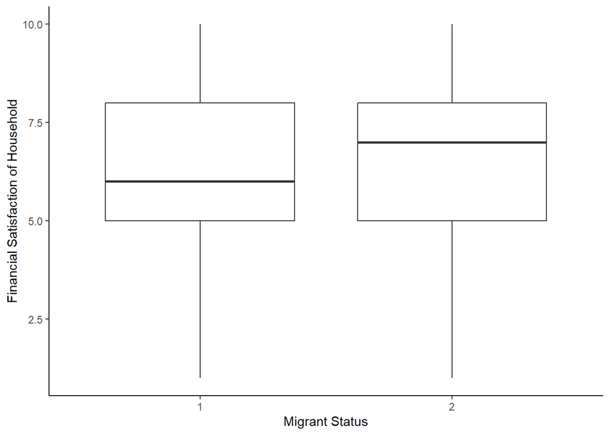

Figure 12. Difference in Means of Financial Satisfaction Level by MS

```r
ggplot(df_imp, aes(x=migrant, y=fin_sat)) +
  geom_boxplot()+
  xlab("Migrant Status")+
  ylab("Financial Satisfaction of Household")+
  theme_classic()
```

In this case, the difference in means is much more observable.

*General Trust*

Here we also should conduct t-test as we have one numeric variable and one binary variable.

```r
t.test(df_imp$fin_sat~df_imp$gen_trust)
```

```
##
##  Welch Two Sample t-test
##
## data:  df_imp$fin_sat by df_imp$gen_trust
## t = 38.546, df = 35920, p-value < 2.2e-16
## alternative hypothesis: true difference in means between group 1 and group 2 is not equal to 0
## 95 percent confidence interval:
##  0.676145 0.748591
## sample estimates:
## mean in group 1 mean in group 2
##        6.756113        6.043745
```

There is a statistically significant difference between those who consider that most people can be trusted and those who consider that they need to be very careful in terms of their financial satisfaction of household level (p-value is less than 0.05). Moreover, those who consider that most people can be trusted have on average higher score on financial satisfaction level compared to the second group.

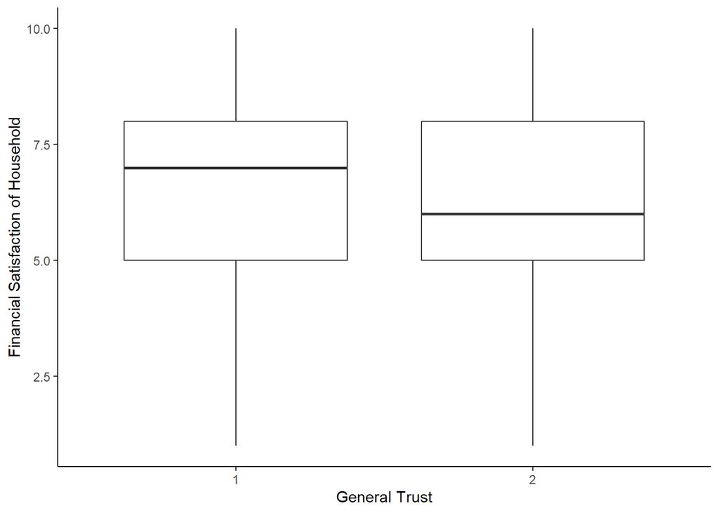

Figure 13. Difference in Means of Financial Satisfaction Level by GT

```r
ggplot(df_imp, aes(x=gen_trust, y=fin_sat)) +
  geom_boxplot()+
  xlab("General Trust")+
  ylab("Financial Satisfaction of Household")+
  theme_classic()
```

In this case as well as in the previous, the difference in means is highly observable.

*God Importance*

Here we should conduct correlation test as we have two numeric variables.

```r
cor.test(df_imp$fin_sat,df_imp$mean_god)
```

```
##
##  Pearson's product-moment correlation
##
## data:  df_imp$fin_sat and df_imp$mean_god
## t = -22.343, df = 78067, p-value < 2.2e-16
## alternative hypothesis: true correlation is not equal to 0
## 95 percent confidence interval:
##  -0.08667948 -0.07273919
## sample estimates:
##         cor
## -0.07971323
```

There is a statistically significant relationship between financial satisfaction level and mean level of God’s importance among countries (p-value is less than 0.05). Moreover, this relationship is negative that means that the higher the level of God’s importance is the less the financial satisfaction is. Also, this relationship is weak because coefficient is only 0.08 by modulus.

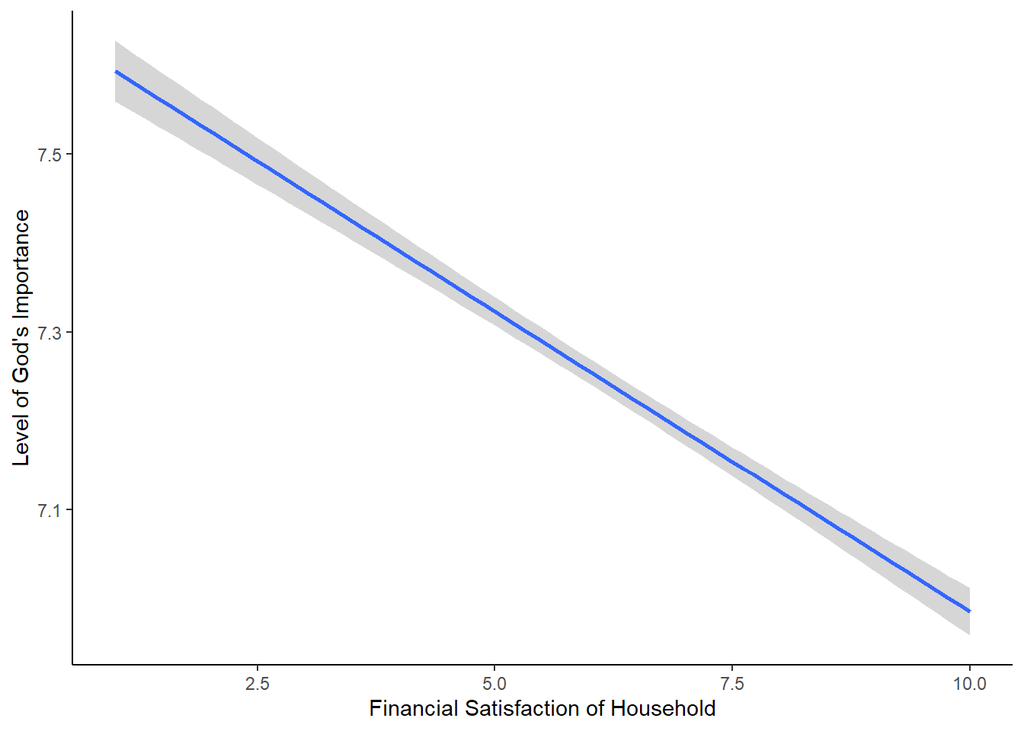

Figure 14. Relationship between Financial Satisfaction and GI

```r
ggplot(df_imp, aes(x = fin_sat, y=mean_god)) +
  xlab("Financial Satisfaction of Household")+
  ylab("Level of God's Importance")+
  geom_smooth(method = "lm")+
  theme_classic()
```

Here is the visualization of this correlation.

*Liberal-Conservative Scale*

Here we should conduct correlation test as we have two numeric variables.

```r
cor.test(df_imp$fin_sat,df_imp$mean_lib_con)
```

```
##
##  Pearson's product-moment correlation
##
## data:  df_imp$fin_sat and df_imp$mean_lib_con
## t = -6.4537, df = 78067, p-value = 1.098e-10
## alternative hypothesis: true correlation is not equal to 0
## 95 percent confidence interval:
##  -0.03010179 -0.01607985
## sample estimates:
##         cor
## -0.02309196
```

There is a statistically significant relationship between financial satisfaction level and mean scale of liberal-conservative views by countries (p-value is less than 0.05). Moreover, this relationship is negative that means that the higher the scale (the closer to the conservative) is the lower the financial satisfaction is. Also, this relationship is weak because coefficient is only 0.02 by modulus.

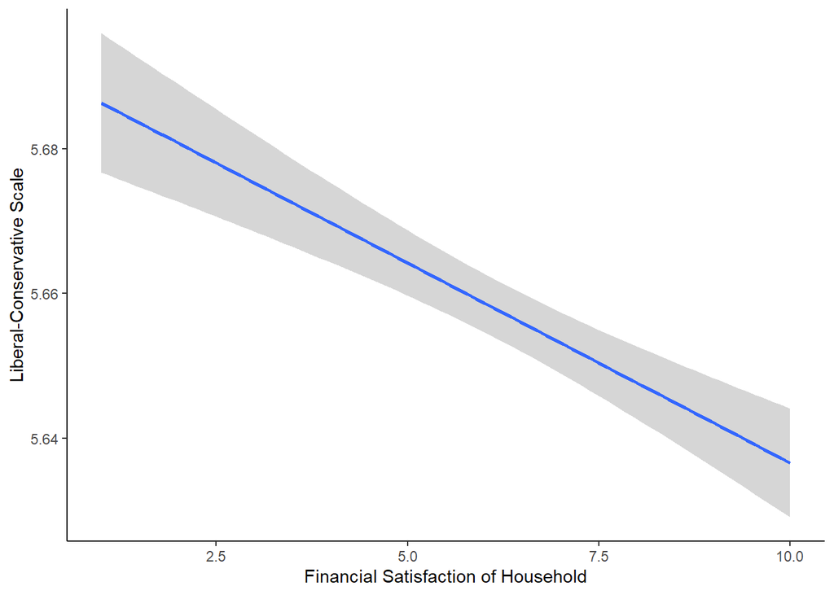

Figure 15. Relationship between Financial Satisfaction and LCS

```r
ggplot(df_imp, aes(x = fin_sat, y=mean_lib_con)) +
  xlab("Financial Satisfaction of Household")+
  ylab("Liberal-Conservative Scale")+
  geom_smooth(method = "lm")+
  theme_classic()
```

Here is the visualization of this correlation.

*Education*

Here we should conduct correlation test as we have two numeric variables.

```r
cor.test(df_imp$fin_sat,df_imp$mean_ed)
```

```
##
##  Pearson's product-moment correlation
##
## data:  df_imp$fin_sat and df_imp$mean_ed
## t = 16.807, df = 78067, p-value < 2.2e-16
## alternative hypothesis: true correlation is not equal to 0
## 95 percent confidence interval:
##  0.05305128 0.06703013
## sample estimates:
##        cor
## 0.06004365
```

There is a statistically significant relationship between financial satisfaction level and mean level of education by countries (p-value is less than 0.05). Moreover, this relationship is positive that means that the higher mean level of education is the higher the financial satisfaction is. Also, this relationship is weak because coefficient is only 0.06 by modulus.

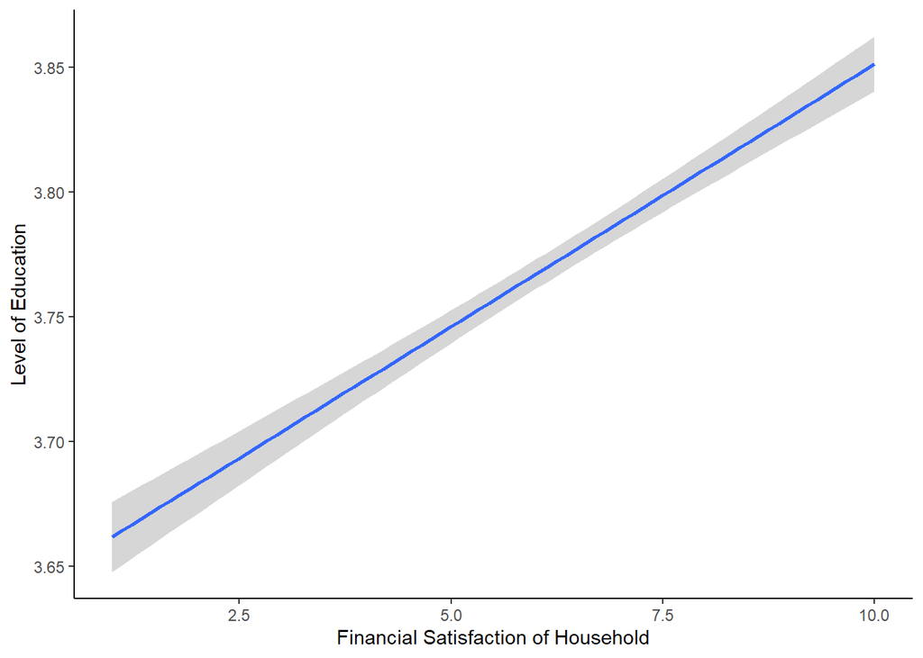

Figure 16. Relationship between Financial Satisfaction and Education

```r
ggplot(df_imp, aes(x = fin_sat, y=mean_ed)) +
  xlab("Financial Satisfaction of Household")+
  ylab("Level of Education")+
  geom_smooth(method = "lm")+
  theme_classic()
```

Here is the visualization of this correlation.

*Country*

Here we should conduct ANOVA because we have more than 2 levels in the categorical variable and one variable is numeric.

```r
summary(aov(fin_sat ~ B_COUNTRY, data = df_imp))
```

```
##                Df Sum Sq Mean Sq F value Pr(>F)
## B_COUNTRY      52  39221   754.2   143.9 <2e-16 ***
## Residuals   78016 408914     5.2
## ---
## Signif. codes:  0 '***' 0.001 '**' 0.01 '*' 0.05 '.' 0.1 ' ' 1
```

There is a statistically significant relationship between financial satisfaction level and countries (p-value is less than 0.05). We should plot the results of ANOVA post-hoc to see between which groups the difference exists.

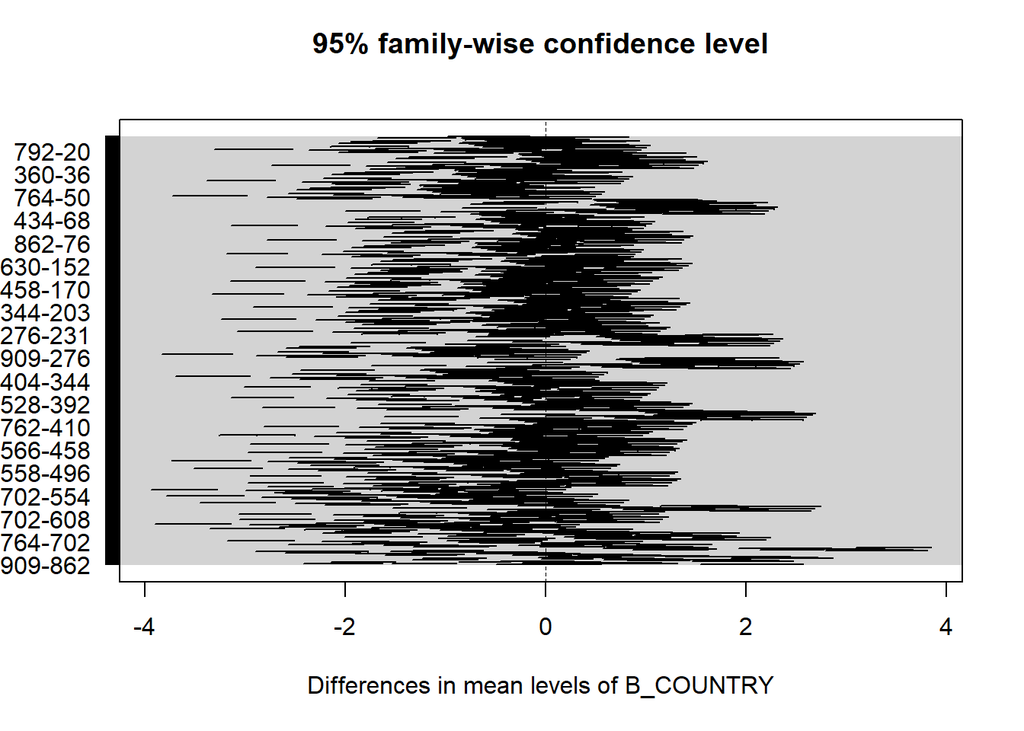

```r
tukey.plot.test<-TukeyHSD(aov(fin_sat ~ B_COUNTRY, data = df_imp))
plot(tukey.plot.test, las = 1)
```

Due to the large number of countries in the dataset, it is hard to distinguish the plot, but we can see that there are differences between different countries.

# 4. Analysis.

In this section we are going to build our model step by step and analyse it. Before starting working with multilevel modeling, let’s check whether it is justifiable to add the second level into our model.

## Justification

Let’s build the null model and check if the value of ICC to justify (or not) the usage of the addition of the second level.

```r
nullmodel <- lmer(fin_sat ~ (1 | B_COUNTRY), data = df_imp, REML = FALSE)
icc(nullmodel)
```

| ICC_adjusted | ICC_unadjusted | optional |
| --- | --- | --- |
| 0.09816125 | 0.09816125 | FALSE |

ICC equals 0.098 that is very good result that justifies our ability to proceed working with second level.

## Model Building (1)

Now let’s add one by one variable to our variable starting with 1st level predictors. We will briefly discuss them and will give the full interpretation to our final model.

```r
model1 <- lmer(fin_sat ~ sex + age + (1 | B_COUNTRY), data = df_imp, REML = FALSE)
tab_model(model1)
```

|  | fin_sat |  |  |
| --- | --- | --- | --- |
| Predictors | Estimates | CI | p |
| (Intercept) | 6.19 | 5.98 – 6.40 | **<0.001** |
| sex [2] | -0.06 | -0.09 – -0.02 | **0.001** |
| age | 0.00 | -0.00 – 0.00 | 0.403 |
| Random Effects |  |  |  |
| σ<sup>2</sup> | 5.24 |  |  |
| τ<sub>00</sub> <sub>B_COUNTRY</sub> | 0.57 |  |  |
| ICC | 0.10 |  |  |
| N <sub>B_COUNTRY</sub> | 53 |  |  |
| Observations | 78069 |  |  |
| Marginal R<sup>2</sup> / Conditional R<sup>2</sup> | 0.000 / 0.098 |  |  |

We added our control variables (sex and age), and we can see that the sex variable is statistically significant in our model (p-value is less than 0.05), however the age is not statistically significant in our model (p-value is more than 0.05). We should take it into account for further steps and be careful with the age variable.

```r
model2 <- lmer(fin_sat ~ sex + age + migrant + (1 | B_COUNTRY), data = df_imp, REML = FALSE)
tab_model(model2)
```

|  | fin_sat |  |  |
| --- | --- | --- | --- |
| Predictors | Estimates | CI | p |
| (Intercept) | 6.19 | 5.98 – 6.40 | **<0.001** |
| sex [2] | -0.06 | -0.09 – -0.02 | **0.001** |
| age | 0.00 | -0.00 – 0.00 | 0.393 |
| migrant [2] | -0.10 | -0.17 – -0.03 | **0.005** |
| Random Effects |  |  |  |
| σ<sup>2</sup> | 5.24 |  |  |
| τ<sub>00</sub> <sub>B_COUNTRY</sub> | 0.57 |  |  |
| ICC | 0.10 |  |  |
| N <sub>B_COUNTRY</sub> | 53 |  |  |
| Observations | 78069 |  |  |
| Marginal R<sup>2</sup> / Conditional R<sup>2</sup> | 0.000 / 0.099 |  |  |

Here we added migrant status variable, and it is statistically significant in our model (p-value is less than 0.05), though the age is still not statistically significant in our model (p-value is more than 0.05).

Is this model better than the first one?

```r
anova(model1, model2)
```

|  | npar | AIC | BIC | logLik | deviance | Chisq | Df | Pr(>Chisq) |
| --- | --- | --- | --- | --- | --- | --- | --- | --- |
| model1 | 5 | 351142.1 | 351188.4 | -175566.0 | 351132.1 | NA | NA | NA |
| model2 | 6 | 351136.2 | 351191.8 | -175562.1 | 351124.2 | 7.87673 | 1 | 0.005007494 |

ANOVA test results are significant (p-value is less than 0.05), so this model is better than the previous one.

```r
model3 <- lmer(fin_sat ~ sex + age + migrant + gen_trust + (1 | B_COUNTRY), data = df_imp, REML = FALSE)
tab_model(model3)
```

|  | fin_sat |  |  |
| --- | --- | --- | --- |
| Predictors | Estimates | CI | p |
| (Intercept) | 6.63 | 6.42 – 6.84 | **<0.001** |
| sex [2] | -0.05 | -0.08 – -0.01 | **0.004** |
| age | 0.00 | -0.00 – 0.00 | 0.609 |
| migrant [2] | -0.09 | -0.16 – -0.02 | **0.015** |
| gen trust [2] | -0.56 | -0.60 – -0.52 | **<0.001** |
| Random Effects |  |  |  |
| σ<sup>2</sup> | 5.19 |  |  |
| τ<sub>00</sub> <sub>B_COUNTRY</sub> | 0.53 |  |  |
| ICC | 0.09 |  |  |
| N <sub>B_COUNTRY</sub> | 53 |  |  |
| Observations | 78069 |  |  |
| Marginal R<sup>2</sup> / Conditional R<sup>2</sup> | 0.010 / 0.102 |  |  |

In this step we added general trust status variable (people can be trusted mostly/you should be very careful), and it is statistically significant in our model (p-value is less than 0.05). Moreover, the age is still not statistically significant in our model (p-value is more than 0.05).

Let’s check whether the third model is better than the second one.

```r
anova(model2, model3)
```

|  | npar | AIC | BIC | logLik | deviance | Chisq | Df | Pr(>Chisq) |
| --- | --- | --- | --- | --- | --- | --- | --- | --- |
| model2 | 6 | 351136.2 | 351191.8 | -175562.1 | 351124.2 | NA | NA | NA |
| model3 | 7 | 350414.9 | 350479.8 | -175200.4 | 350400.9 | 723.3281 | 1 | 2.529102e-159 |

ANOVA test results are significant (p-value is less than 0.05), so this model is better than the previous one.

```r
model3.1 <- lmer(fin_sat ~ sex + age + migrant + gen_trust + mean_god + (1 | B_COUNTRY), data = df_imp, REML = FALSE)
tab_model(model3.1)
```

|  | fin_sat |  |  |
| --- | --- | --- | --- |
| Predictors | Estimates | CI | p |
| (Intercept) | 7.07 | 6.31 – 7.82 | **<0.001** |
| sex [2] | -0.05 | -0.08 – -0.01 | **0.004** |
| age | 0.00 | -0.00 – 0.00 | 0.626 |
| migrant [2] | -0.09 | -0.16 – -0.02 | **0.014** |
| gen trust [2] | -0.56 | -0.60 – -0.52 | **<0.001** |
| mean god | -0.06 | -0.16 – 0.04 | 0.241 |
| Random Effects |  |  |  |
| σ<sup>2</sup> | 5.19 |  |  |
| τ<sub>00</sub> <sub>B_COUNTRY</sub> | 0.52 |  |  |
| ICC | 0.09 |  |  |
| N <sub>B_COUNTRY</sub> | 53 |  |  |
| Observations | 78069 |  |  |
| Marginal R<sup>2</sup> / Conditional R<sup>2</sup> | 0.016 / 0.105 |  |  |

```r
anova(model3, model3.1)
```

|  | npar | AIC | BIC | logLik | deviance | Chisq | Df | Pr(>Chisq) |
| --- | --- | --- | --- | --- | --- | --- | --- | --- |
| model3 | 7 | 350414.9 | 350479.8 | -175200.4 | 350400.9 | NA | NA | NA |
| model3.1 | 8 | 350415.5 | 350489.7 | -175199.8 | 350399.5 | 1.357199 | 1 | 0.2440235 |

ANOVA test results are not significant (p-value is more than 0.05), so this model is not better than the previous one.

```r
model3.2 <- lmer(fin_sat ~ sex + age + migrant + gen_trust + mean_god + mean_lib_con + (1 | B_COUNTRY), data = df_imp, REML = FALSE)
tab_model(model3.2)
```

|  | fin_sat |  |  |
| --- | --- | --- | --- |
| Predictors | Estimates | CI | p |
| (Intercept) | 6.60 | 4.71 – 8.48 | **<0.001** |
| sex [2] | -0.05 | -0.08 – -0.01 | **0.004** |
| age | 0.00 | -0.00 – 0.00 | 0.624 |
| migrant [2] | -0.09 | -0.16 – -0.02 | **0.015** |
| gen trust [2] | -0.56 | -0.60 – -0.52 | **<0.001** |
| mean god | -0.07 | -0.18 – 0.04 | 0.198 |
| mean lib con | 0.10 | -0.27 – 0.47 | 0.594 |
| Random Effects |  |  |  |
| σ<sup>2</sup> | 5.19 |  |  |
| τ<sub>00</sub> <sub>B_COUNTRY</sub> | 0.52 |  |  |
| ICC | 0.09 |  |  |
| N <sub>B_COUNTRY</sub> | 53 |  |  |
| Observations | 78069 |  |  |
| Marginal R<sup>2</sup> / Conditional R<sup>2</sup> | 0.016 / 0.105 |  |  |

```r
anova(model3, model3.2)
```

|  | npar | AIC | BIC | logLik | deviance | Chisq | Df | Pr(>Chisq) |
| --- | --- | --- | --- | --- | --- | --- | --- | --- |
| model3 | 7 | 350414.9 | 350479.8 | -175200.4 | 350400.9 | NA | NA | NA |
| model3.2 | 9 | 350417.3 | 350500.6 | -175199.6 | 350399.3 | 1.640235 | 2 | 0.4403799 |

ANOVA test results are again not significant (p-value is more than 0.05), so this model is not better than the model without second level predictors.

```r
model3.3 <- lmer(fin_sat ~ sex + age + migrant + gen_trust + mean_god + mean_lib_con + mean_ed + (1 | B_COUNTRY), data = df_imp, REML = FALSE)
tab_model(model3.3)
```

|  | fin_sat |  |  |
| --- | --- | --- | --- |
| Predictors | Estimates | CI | p |
| (Intercept) | 5.88 | 3.18 – 8.58 | **<0.001** |
| sex [2] | -0.05 | -0.08 – -0.01 | **0.004** |
| age | 0.00 | -0.00 – 0.00 | 0.625 |
| migrant [2] | -0.09 | -0.16 – -0.02 | **0.014** |
| gen trust [2] | -0.56 | -0.60 – -0.52 | **<0.001** |
| mean god | -0.06 | -0.18 – 0.06 | 0.336 |
| mean lib con | 0.14 | -0.24 – 0.52 | 0.478 |
| mean ed | 0.11 | -0.18 – 0.39 | 0.467 |
| Random Effects |  |  |  |
| σ<sup>2</sup> | 5.19 |  |  |
| τ<sub>00</sub> <sub>B_COUNTRY</sub> | 0.51 |  |  |
| ICC | 0.09 |  |  |
| N <sub>B_COUNTRY</sub> | 53 |  |  |
| Observations | 78069 |  |  |
| Marginal R<sup>2</sup> / Conditional R<sup>2</sup> | 0.018 / 0.106 |  |  |

```r
anova(model3, model3.3)
```

|  | npar | AIC | BIC | logLik | deviance | Chisq | Df | Pr(>Chisq) |
| --- | --- | --- | --- | --- | --- | --- | --- | --- |
| model3 | 7 | 350414.9 | 350479.8 | -175200.4 | 350400.9 | NA | NA | NA |
| model3.3 | 10 | 350418.7 | 350511.4 | -175199.4 | 350398.7 | 2.166499 | 3 | 0.5385771 |

ANOVA test results are again not significant (p-value is more than 0.05), so this model is not better than the model without mean variables. Thus, we will not include last three variables into our final model, but later we will try to include them as random slopes.

Let’s try to exclude age variable from the model and leave sex, migrant status, general trust and country, and compare it with the same model with age.

```r
model3.4 <- lmer(fin_sat ~ sex + migrant + gen_trust + (1 | B_COUNTRY), data = df_imp, REML = FALSE)
anova(model3, model3.4)
```

|  | npar | AIC | BIC | logLik | deviance | Chisq | Df | Pr(>Chisq) |
| --- | --- | --- | --- | --- | --- | --- | --- | --- |
| model3.4 | 6 | 350413.2 | 350468.7 | -175200.6 | 350401.2 | NA | NA | NA |
| model3 | 7 | 350414.9 | 350479.8 | -175200.4 | 350400.9 | 0.261535 | 1 | 0.6090675 |

ANOVA test results are again not significant (p-value is more than 0.05), so this new model is not better than the model with age, so we will stick to the model with age.

## Model Diagnostics (1)

As for now the summary of our 1st stage model looks like this:

```r
tab_model(model3)
```

|  | fin_sat |  |  |
| --- | --- | --- | --- |
| Predictors | Estimates | CI | p |
| (Intercept) | 6.63 | 6.42 – 6.84 | **<0.001** |
| sex [2] | -0.05 | -0.08 – -0.01 | **0.004** |
| age | 0.00 | -0.00 – 0.00 | 0.609 |
| migrant [2] | -0.09 | -0.16 – -0.02 | **0.015** |
| gen trust [2] | -0.56 | -0.60 – -0.52 | **<0.001** |
| Random Effects |  |  |  |
| σ<sup>2</sup> | 5.19 |  |  |
| τ<sub>00</sub> <sub>B_COUNTRY</sub> | 0.53 |  |  |
| ICC | 0.09 |  |  |
| N <sub>B_COUNTRY</sub> | 53 |  |  |
| Observations | 78069 |  |  |
| Marginal R<sup>2</sup> / Conditional R<sup>2</sup> | 0.010 / 0.102 |  |  |

Predictors:

- The intercept is 6.63, indicating the average financial satisfaction of household level when all other predictors are at 0.
- Sex has a negative effect with an estimate of -0.05.
- Age has no statistically significant effect as p-value is more than 0.05.
- Migrant status has a negative effect with an estimate of -0.09.
- General trust has a negative effect with an estimate of -0.56.

Random Effects:

- The variance is 5.19.
- The random intercept for the variable “B_COUNTRY” has a variance of 0.53.
- The Intra-class correlation coefficient (ICC) is 0.09.

Other:

- The Marginal R2 is 0.01, indicating that the fixed effects explain 1% of the variance in financial satisfaction of household level
- The Conditional R2 is 0.102, suggesting that the model with both fixed and random effects explains 10.2% of the variance.

Interpretation:

- The model suggests that sex, migrant status, and general trust have significant effects on financial satisfaction of household level
- The random intercept for B_COUNTRY (τ00 B_COUNTRY) captures the variability in the average financial satisfaction of household level between countries that is not explained by the fixed effects.
- The ICC of 0.09 indicates that there is a moderate amount of variability in financial satisfaction of household level that can be attributed to differences between countries.

Overall, the model explains a modest amount of variance in financial satisfaction of household level, and the predictors sex, migrant status, and general trust all have significant effects on the outcome.

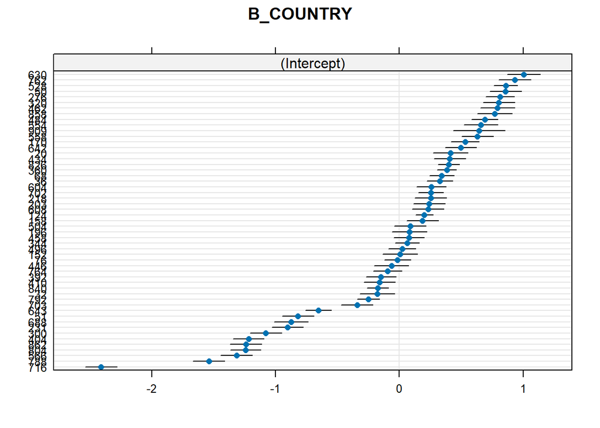

```r
dotplot(ranef(model3, condVar=TRUE))
```

Here we can see how the intercept changes for different countries. There are many countries which confidence intervals do not overlap, though some of them overlap anyway.

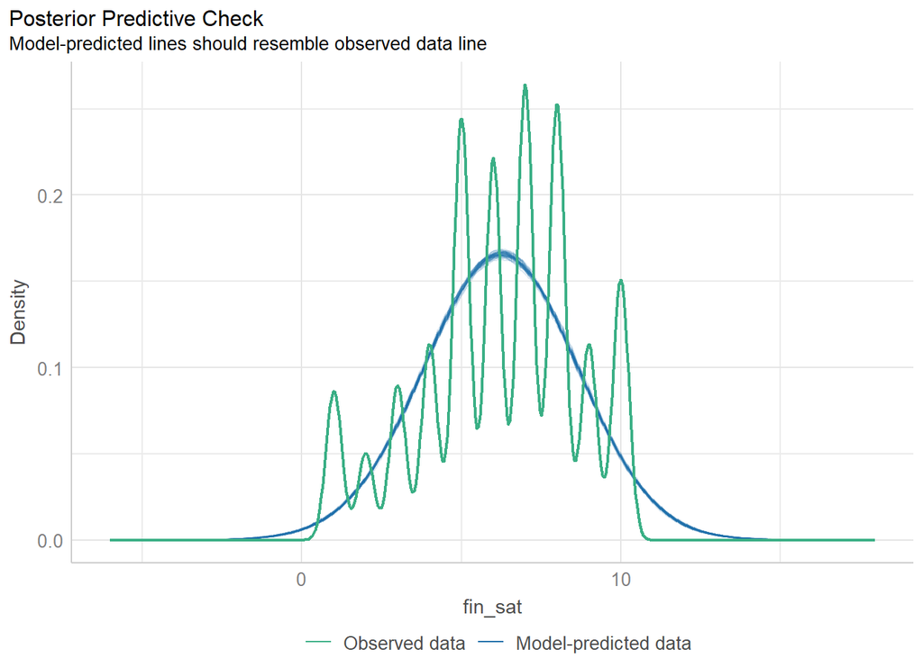

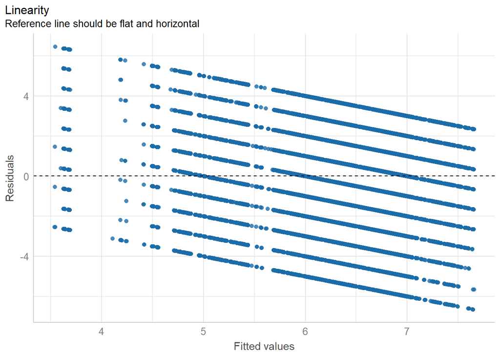

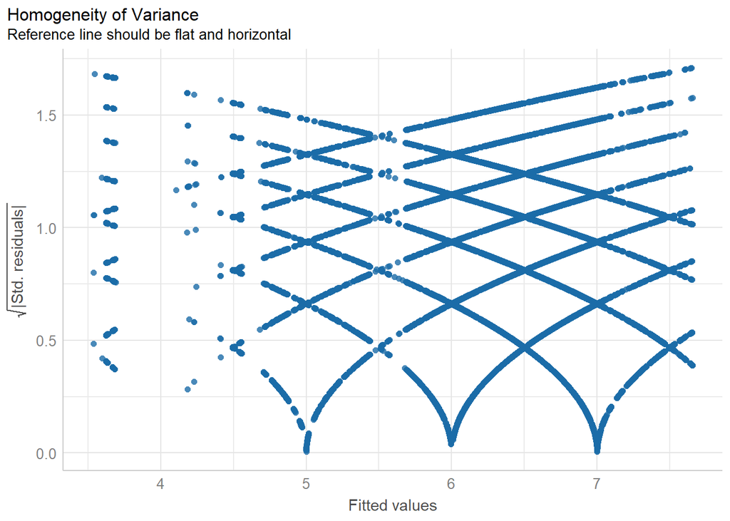

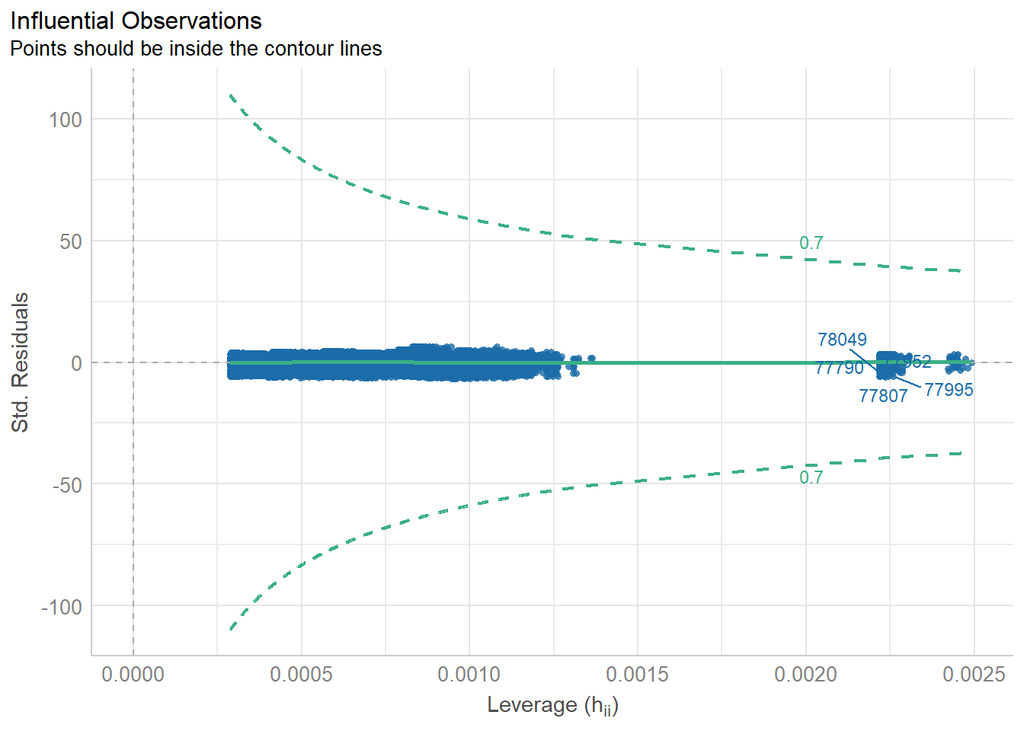

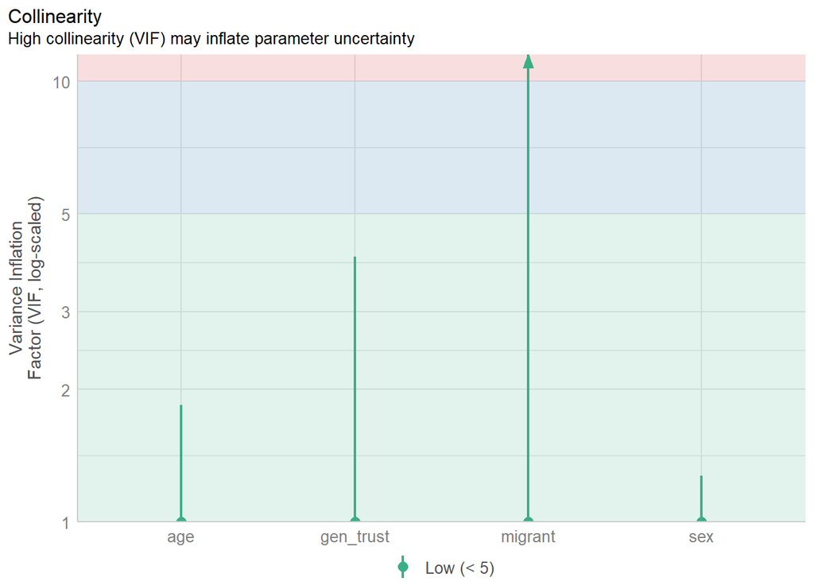

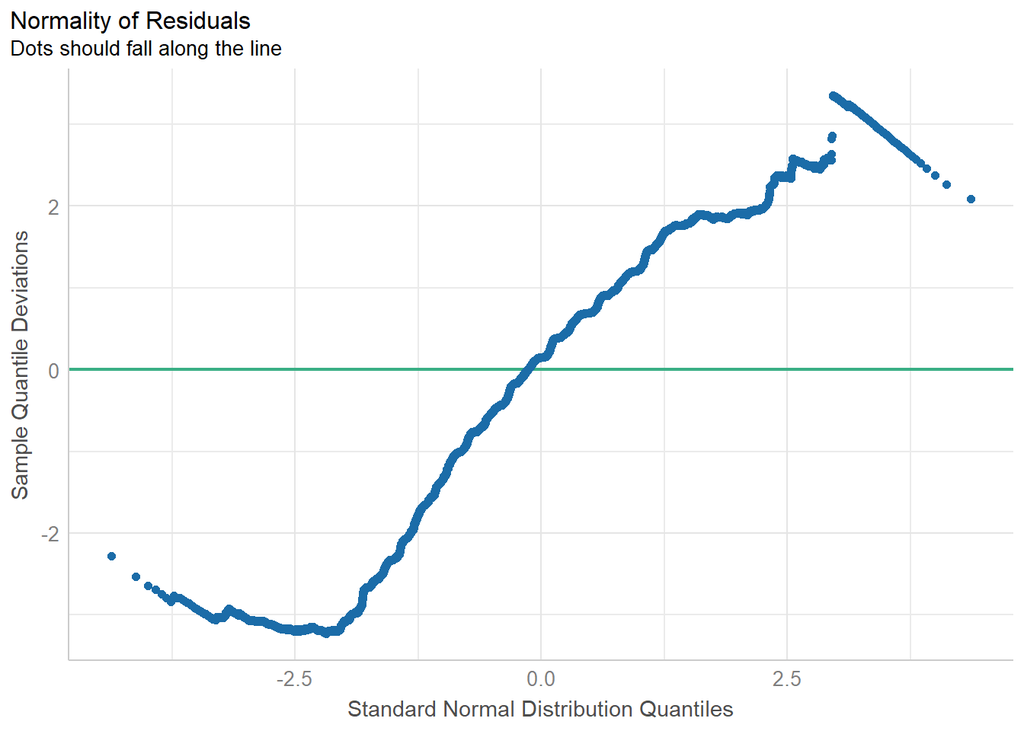

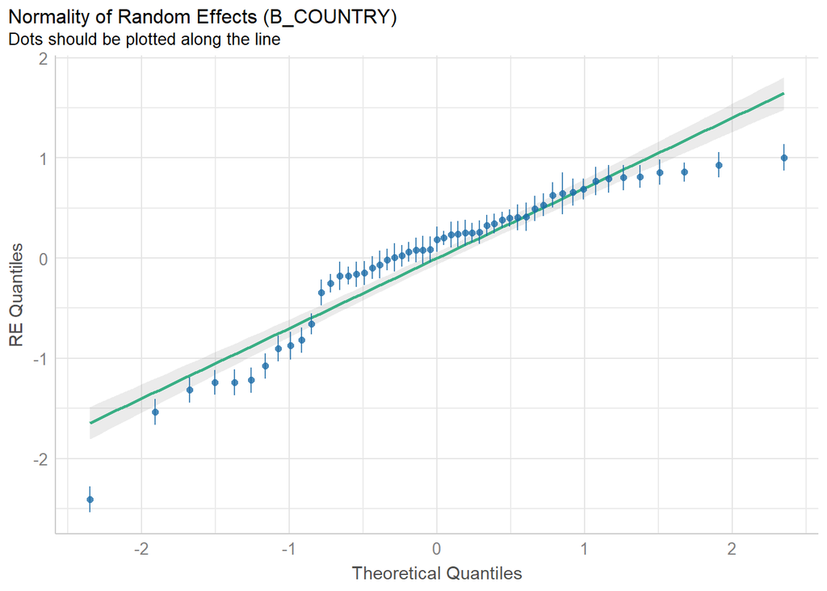

```r
graph0 <- performance::check_model(model3, panel = F, verbose = T)
plot(graph0)
```

Here we have 7 different plots to diagnose our model, so let’s analyse it one by one.

1. This plot shows us the distributions of observed data and model-predicted data. The latest really tries to resemble the initial data, however it turns out to be not so good, because the outcome variable is a scale from 1 to 10 without some decimal points. In general, it’s not the worst scenario we could obtain.
2. This plot shows linearity. It is not very bad.
3. This plot shows homogeneity of variance. It could be better, but it is what it is.
4. This plot describes leverages. We can say that there are not so many leverages, that’s good.
5. This plot shows whether we have multicolinearity among our predictors. Bad news - we have a multicolinearity in case of migrant status. Let’s double check it with a special test.

```r
car::vif(model3)
```

```
##       sex       age   migrant gen_trust
##  1.001320  1.001051  1.000275  1.000862
```

No, it is actually all good, as VIFs are less than 4.

6. This plot describes the normality of residuals. Though dots do not follow the green line, we may assume that for multilevel modelling it is a fine situation (according to Yaroslav Snarskiy, it is ok).
7. This graph shows the normality of random effects, and we can see that in this case dots follow the lines, that means that we have justified the usage of multilevel modelling with country variable.

## Model Building (2)

```r
model4 <- lmer(fin_sat ~ sex + age + migrant + gen_trust + mean_god + (1 + mean_god | B_COUNTRY), data = df_imp, REML = FALSE)
tab_model(model4)
```

|  | fin_sat |  |  |
| --- | --- | --- | --- |
| Predictors | Estimates | CI | p |
| (Intercept) | 7.34 | 6.85 – 7.84 | **<0.001** |
| sex [2] | -0.05 | -0.08 – -0.01 | **0.004** |
| age | 0.00 | -0.00 – 0.00 | 0.605 |
| migrant [2] | -0.09 | -0.16 – -0.02 | **0.016** |
| gen trust [2] | -0.56 | -0.60 – -0.52 | **<0.001** |
| mean god | -0.10 | -0.18 – -0.02 | **0.015** |
| Random Effects |  |  |  |
| σ<sup>2</sup> | 5.19 |  |  |
| τ<sub>00</sub> <sub>B_COUNTRY</sub> | 0.78 |  |  |
| τ<sub>11</sub> <sub>B_COUNTRY.mean_god</sub> | 0.04 |  |  |
| ρ<sub>01</sub> <sub>B_COUNTRY</sub> | -0.94 |  |  |
| ICC | 0.09 |  |  |
| N <sub>B_COUNTRY</sub> | 53 |  |  |
| Observations | 78069 |  |  |
| Marginal R<sup>2</sup> / Conditional R<sup>2</sup> | 0.023 / 0.113 |  |  |

Here we start adding our second level predictors and making Random Slope Model. We can see that mean God’s importance is statistically significant (p-value is less than 0.05). It means that the effect of mean God’s importance is different among countries.

Let’s conduct ANOVA test to see whether it makes sense to keep effect as random.

```r
anova(model3, model4)
```

|  | npar | AIC | BIC | logLik | deviance | Chisq | Df | Pr(>Chisq) |
| --- | --- | --- | --- | --- | --- | --- | --- | --- |
| model3 | 7 | 350414.9 | 350479.8 | -175200.4 | 350400.9 | NA | NA | NA |
| model4 | 10 | 350404.4 | 350497.1 | -175192.2 | 350384.4 | 16.46676 | 3 | 0.0009095765 |

ANOVA test results are significant, so it makes sense to keep the effect as random.

```r
model5 <- lmer(fin_sat ~ sex + age + migrant + gen_trust + mean_god + mean_lib_con + (1 + mean_god + mean_lib_con| B_COUNTRY), data = df_imp, REML = FALSE)
tab_model(model5)
```

|  | fin_sat |  |  |
| --- | --- | --- | --- |
| Predictors | Estimates | CI | p |
| (Intercept) | 8.76 | 7.49 – 10.03 | **<0.001** |
| sex [2] | -0.05 | -0.08 – -0.01 | **0.004** |
| age | 0.00 | -0.00 – 0.00 | 0.618 |
| migrant [2] | -0.08 | -0.16 – -0.01 | **0.017** |
| gen trust [2] | -0.56 | -0.60 – -0.52 | **<0.001** |
| mean god | -0.08 | -0.16 – 0.01 | 0.080 |
| mean lib con | -0.30 | -0.51 – -0.09 | **0.006** |
| Random Effects |  |  |  |
| σ<sup>2</sup> | 5.19 |  |  |
| τ<sub>00</sub> <sub>B_COUNTRY</sub> | 4.61 |  |  |
| τ<sub>11</sub> <sub>B_COUNTRY.mean_god</sub> | 0.07 |  |  |
| τ<sub>11</sub> <sub>B_COUNTRY.mean_lib_con</sub> | 0.07 |  |  |
| ρ<sub>01</sub> | -0.66 |  |  |
|  | -0.78 |  |  |
| ICC | 0.11 |  |  |
| N <sub>B_COUNTRY</sub> | 53 |  |  |
| Observations | 78069 |  |  |
| Marginal R<sup>2</sup> / Conditional R<sup>2</sup> | 0.029 / 0.139 |  |  |

```r
anova(model4, model5)
```

|  | npar | AIC | BIC | logLik | deviance | Chisq | Df | Pr(>Chisq) |
| --- | --- | --- | --- | --- | --- | --- | --- | --- |
| model4 | 10 | 350404.4 | 350497.1 | -175192.2 | 350384.4 | NA | NA | NA |
| model5 | 14 | 350409.3 | 350539.0 | -175190.6 | 350381.3 | 3.157433 | 4 | 0.5318335 |

ANOVA test results also tell us that this model is not better than the previous one.

Let’s make a step back and insert liberal-conservative scale variable instead of God’s importance.

```r
model4.1 <- lmer(fin_sat ~ sex + age + migrant + gen_trust + mean_lib_con + (1 + mean_lib_con | B_COUNTRY), data = df_imp, REML = FALSE)
tab_model(model4.1)
```

|  | fin_sat |  |  |
| --- | --- | --- | --- |
| Predictors | Estimates | CI | p |
| (Intercept) | 7.33 | 5.58 – 9.07 | **<0.001** |
| sex [2] | -0.05 | -0.08 – -0.01 | **0.004** |
| age | 0.00 | -0.00 – 0.00 | 0.608 |
| migrant [2] | -0.09 | -0.16 – -0.02 | **0.015** |
| gen trust [2] | -0.56 | -0.60 – -0.52 | **<0.001** |
| mean lib con | -0.12 | -0.44 – 0.19 | 0.444 |
| Random Effects |  |  |  |
| σ<sup>2</sup> | 5.19 |  |  |
| τ<sub>00</sub> <sub>B_COUNTRY</sub> | 0.11 |  |  |
| τ<sub>11</sub> <sub>B_COUNTRY.mean_lib_con</sub> | 0.04 |  |  |
| ρ<sub>01</sub> <sub>B_COUNTRY</sub> | -1.00 |  |  |
| ICC | 0.09 |  |  |
| N <sub>B_COUNTRY</sub> | 53 |  |  |
| Observations | 78069 |  |  |
| Marginal R<sup>2</sup> / Conditional R<sup>2</sup> | 0.012 / 0.105 |  |  |

We can see that this variable is still not statistically significant (p-value is more than 0.05). Thus, we may not use it for further steps.

Now let’s add the last possible second level predictor.

```r
model6 <- lmer(fin_sat ~ sex + age + migrant + gen_trust + mean_god + mean_ed + (1 + mean_god + mean_ed| B_COUNTRY), data = df_imp, REML = FALSE)
tab_model(model6)
```

|  | fin_sat |  |  |
| --- | --- | --- | --- |
| Predictors | Estimates | CI | p |
| (Intercept) | 8.12 | 6.70 – 9.54 | **<0.001** |
| sex [2] | -0.05 | -0.08 – -0.01 | **0.004** |
| age | 0.00 | -0.00 – 0.00 | 0.589 |
| migrant [2] | -0.09 | -0.16 – -0.02 | **0.016** |
| gen trust [2] | -0.56 | -0.60 – -0.52 | **<0.001** |
| mean god | -0.15 | -0.25 – -0.04 | **0.005** |
| mean ed | -0.12 | -0.33 – 0.09 | 0.275 |
| Random Effects |  |  |  |
| σ<sup>2</sup> | 5.19 |  |  |
| τ<sub>00</sub> <sub>B_COUNTRY</sub> | 9.50 |  |  |
| τ<sub>11</sub> <sub>B_COUNTRY.mean_god</sub> | 0.07 |  |  |
| τ<sub>11</sub> <sub>B_COUNTRY.mean_ed</sub> | 0.18 |  |  |
| ρ<sub>01</sub> | -0.85 |  |  |
|  | -0.95 |  |  |
| N <sub>B_COUNTRY</sub> | 53 |  |  |
| Observations | 78069 |  |  |
| Marginal R<sup>2</sup> / Conditional R<sup>2</sup> | 0.030 / NA |  |  |

This predictor is not statistically significant as well. That’s sad :(

```r
anova(model4, model6)
```

|  | npar | AIC | BIC | logLik | deviance | Chisq | Df | Pr(>Chisq) |
| --- | --- | --- | --- | --- | --- | --- | --- | --- |
| model4 | 10 | 350404.4 | 350497.1 | -175192.2 | 350384.4 | NA | NA | NA |
| model6 | 14 | 350409.2 | 350538.9 | -175190.6 | 350381.2 | 3.21108 | 4 | 0.5231433 |

ANOVA test results also tell us that this model is not better than the previous one.

Let’s make two steps back.

```r
model4.2 <- lmer(fin_sat ~ sex + age + migrant + gen_trust + mean_ed + (1 + mean_ed | B_COUNTRY), data = df_imp, REML = FALSE)
tab_model(model4.2)
```

|  | fin_sat |  |  |
| --- | --- | --- | --- |
| Predictors | Estimates | CI | p |
| (Intercept) | 5.99 | 4.90 – 7.09 | **<0.001** |
| sex [2] | -0.05 | -0.08 – -0.01 | **0.004** |
| age | 0.00 | -0.00 – 0.00 | 0.610 |
| migrant [2] | -0.09 | -0.16 – -0.02 | **0.016** |
| gen trust [2] | -0.56 | -0.60 – -0.52 | **<0.001** |
| mean ed | 0.20 | -0.08 – 0.47 | 0.162 |
| Random Effects |  |  |  |
| σ<sup>2</sup> | 5.19 |  |  |
| τ<sub>00</sub> <sub>B_COUNTRY</sub> | 10.26 |  |  |
| τ<sub>11</sub> <sub>B_COUNTRY.mean_ed</sub> | 0.64 |  |  |
| ρ<sub>01</sub> <sub>B_COUNTRY</sub> | -0.99 |  |  |
| ICC | 0.10 |  |  |
| N <sub>B_COUNTRY</sub> | 53 |  |  |
| Observations | 78069 |  |  |
| Marginal R<sup>2</sup> / Conditional R<sup>2</sup> | 0.017 / 0.120 |  |  |

Here the predictor is also not statistically significant as well, so we should eliminate it from our final model.

## Model Diagnostics (2)

Therefore, our final model look like this:
$$fin.sat \sim sex + age + migrant + gen.trust + mean.god + (1 + mean.god | country)$$

And its summary is:

```r
tab_model(model4)
```

|  | fin_sat |  |  |
| --- | --- | --- | --- |
| Predictors | Estimates | CI | p |
| (Intercept) | 7.34 | 6.85 – 7.84 | **<0.001** |
| sex [2] | -0.05 | -0.08 – -0.01 | **0.004** |
| age | 0.00 | -0.00 – 0.00 | 0.605 |
| migrant [2] | -0.09 | -0.16 – -0.02 | **0.016** |
| gen trust [2] | -0.56 | -0.60 – -0.52 | **<0.001** |
| mean god | -0.10 | -0.18 – -0.02 | **0.015** |
| Random Effects |  |  |  |
| σ<sup>2</sup> | 5.19 |  |  |
| τ<sub>00</sub> <sub>B_COUNTRY</sub> | 0.78 |  |  |
| τ<sub>11</sub> <sub>B_COUNTRY.mean_god</sub> | 0.04 |  |  |
| ρ<sub>01</sub> <sub>B_COUNTRY</sub> | -0.94 |  |  |
| ICC | 0.09 |  |  |
| N <sub>B_COUNTRY</sub> | 53 |  |  |
| Observations | 78069 |  |  |
| Marginal R<sup>2</sup> / Conditional R<sup>2</sup> | 0.023 / 0.113 |  |  |

Predictors:

- The intercept is 7.34, indicating the average financial satisfaction improvement when all other predictors are at 0.
- Sex has a negative effect with an estimate of -0.05.
- Age has no statistically significant effect.
- Migrant status has a negative effect with an estimate of -0.09.
- General trust has a negative effect with an estimate of -0.56.
- Mean God importance has a negative effect with an estimate of -0.10.

Random Effects:

Interpretation:

```r
performance(model4)
```

| AIC | AICc | BIC | R2_conditional | R2_marginal | ICC | RMSE | Sigma |
| --- | --- | --- | --- | --- | --- | --- | --- |
| 350442.8 | 350442.8 | 350535.5 | 0.1130642 | 0.02281682 | 0.09235464 | 2.277819 | 2.278582 |

We can see that the ICC is still around 0.09 points. That justifies usage of MLM.

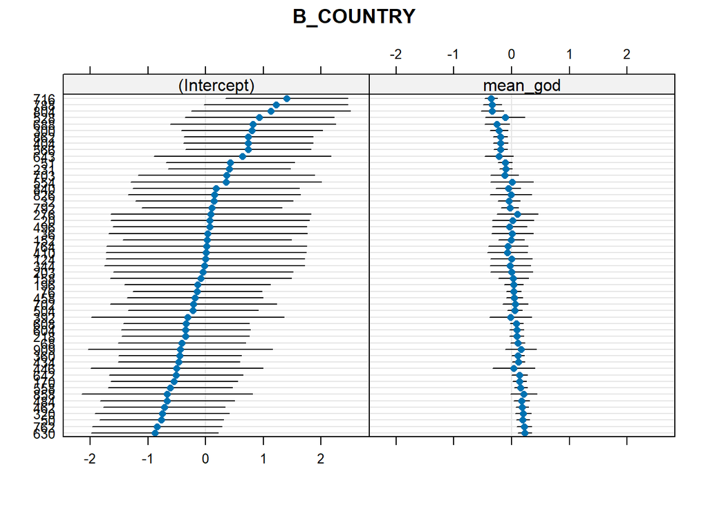

```r
dotplot(ranef(model4, condVar=TRUE))
```

Here we can see that mean God importance variable have different confidence intervals among countries.